# Project 1: What do people around the globe find more important?

Friday, July 18, 2016

## What do people around the golbe find important in their lives?

- family
- friends
- leisure time
- politics
- religion
- work

## Data

- The World Values Survey
- 323,200 respondents from around the world
- 25 years (1990-2015)
- 99 countries

## Question1: Do males and females around the world differ in what they value the most?

[figure not shown]

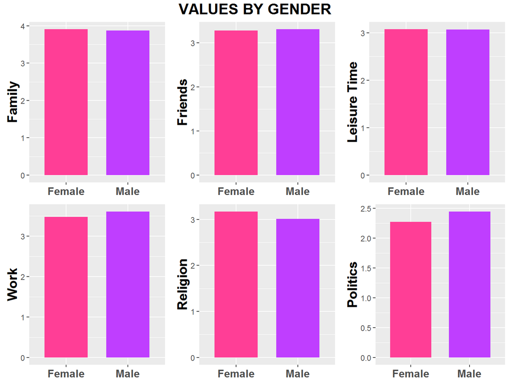

## Question2: Do happy and unhappy people around the world differ in what they value the most?

[figure not shown]

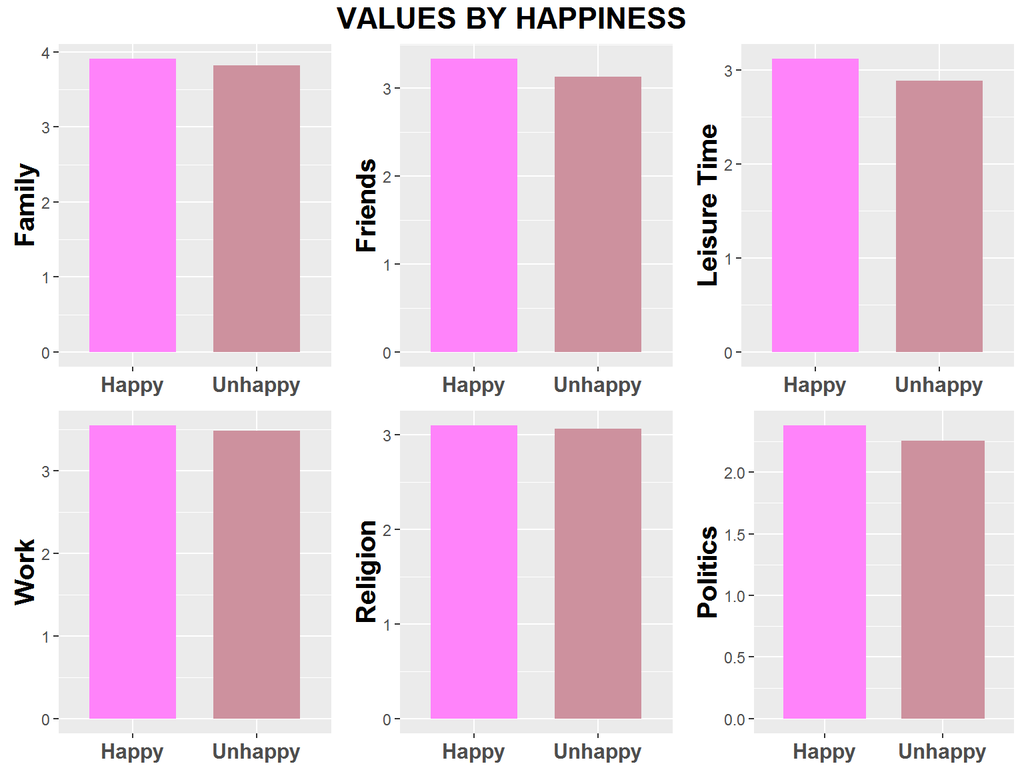

## Question3: Are there any income differences?

[figure not shown]

[figure not shown]

## Question 4: Are there any changes with time?

[figure not shown]

[figure not shown]

## Question 5: Are there any cultural differences?

[figure not shown]

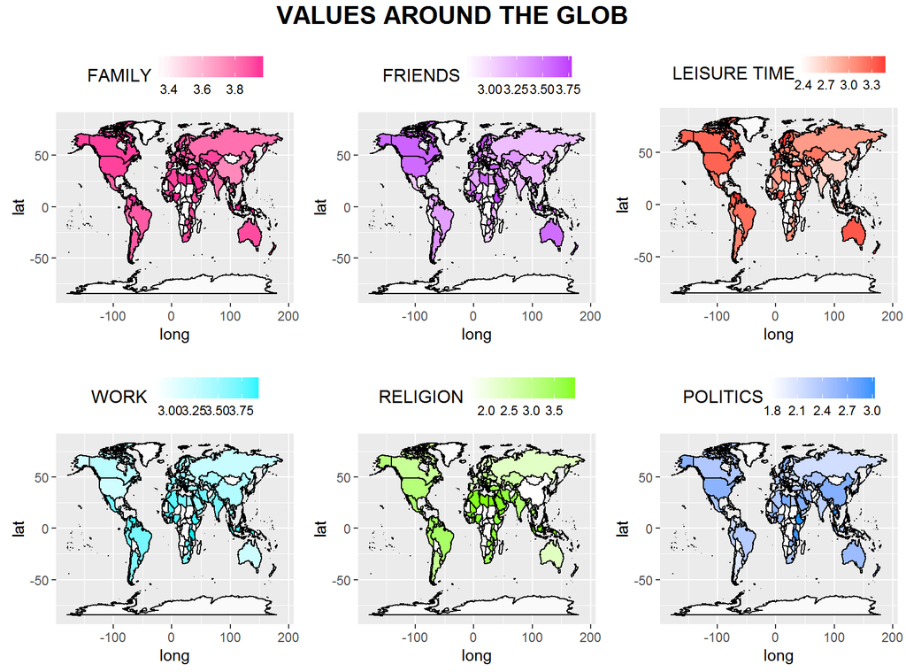

## Summary

-Both genders find family, friends, and leisure time equally important. Males give more importance to politics and work, while females value religion more.

-Happy people vs. unhappy people find all six values more important in their lives. The gap is not that large for work and religion.

## Summary (cont.)

-Although these findings are counterintuitive, people in Asia and Eastern Europe seem to find family slightly less important than people in North American, South America, Western Europe, Africa, and Australia.

-Friends are less important in Asia, Eastern Europe, Mexico, Western Europe, and some parts of Africa.

-Leisure time is valued the most in North America, Mexico, Brazil, some parts of Europe, Kazakhstan, Australia, and some parts of South Africa.

## Summary (cont.)

-People give more importance to work in Mexico, South America, Africa, and Western Europe.

-Religion is more important for people in Africa, Middle East, North America, and South America. People from Russia , China, and Australia do not find religion that important in their lives.